# ＃Pythonの特徴

## 1. シンプル

文法がシンプルで書きやすい。  
また、シンプルが故に可読性が高い。

- 型宣言が必要ない
- セミコロンが必要ない
- インデントによりブロックを示す ・・・ etc

＜例＞  
0,1,2を連続で出力

■C言語の場合 (jupyter notebookはC言語未対応です)

```python
int num = 3;
for(int i = 0; i < num; i++){
    printf("%d¥n", i);
}
```

■Pythonの場合

```python
num = 3
print(type(num))

for i in range(num):
    print(i)
```

```
<class 'int'>
0
1
2
```

## 2. 豊富なライブラリ

数値計算、統計処理、自然言語処理、機械学習等のライブラリが充実している。  
そのため、AIの実装にはPythonが使われることが多い。

| ライブラリ名 | ライブラリの説明 |
| --- | --- |
| Numpy | 配列やベクトルなど、数値計算を行う為のライブラリ |
| Scipy | 科学計算の為のライブラリ |
| Matplotlib | グラフを描画する際に使うライブラリ |
| Pandas | データ解析の為のライブラリ |
| scikit-learn | 機械学習用のライブラリ |

# ＃Python実践

## 0. 目次

1. 出力
2. 変数
3. リスト
4. if文
5. for文
6. 関数

## 1. 出力

### 1.1. 文字列の出力

文字列の出力にはprint関数を用いる。  
文字列として出力するためには文章を ' '（シングルコーテーション）もしくは " "（ダブルコーテーション）で囲む必要がある。

```python
print("Hello World")
```

```
Hello World
```

#### 問題１.１： 以下の文字列を出力してみましょう （30秒）

Good morning!

```python
print("Good morning!")
```

```
Good morning!
```

### 1.2. 文字列以外の出力

文字列以外は ' '（シングルコーテーション）もしくは " "（ダブルコーテーション）で囲わない。

```python
print(1)
```

```
1
```

■数値の計算

| 代数演算子 | 意味 | 例 |
| --- | --- | --- |
| + | 加算 | 5 + 3 =8 |
| - | 減算 | 5 - 3 = 2 |
| * | 乗算 | 5 * 3 = 15 |
| / | 除算 | 5 / 3 = 1.66 |
| % | 余り | 5 % 3 = 2 |

```python
print(5 + 3)
print(5 - 3)
print(5 * 3)
print(5 / 3)
print(5 % 3)
```

```
8
2
15
1.6666666666666667
2
```

#### 問題１.２： 以下の問題を解いてみましょう。（1分30秒）

1. 8を出力をしてみよう。

```python
print(8)
```

```
8
```

1. 8 + 3の計算結果を出力してみよう。

```python
print(8 + 3)
```

```
11
```

1. 8 + 3を「文字列」として出力してみよう。

```python
print("8 + 3")
```

```
8 + 3
```

## 2. 変数

変数はデータを格納するための箱。  
変数を用意することで、変数に値を代入したり、変数から値を出力することができる。

※ プログラムにおける「=」は等しいではなく代入という意味

```python
# 変数my_varに100を「代入」
my_var = 100
print(my_var)
```

```
100
```

```python
# 変数my_varに200を「代入」
# 変数my_varの中身が100→200に上書き
my_var = 200
print(my_var)
```

```
200
```

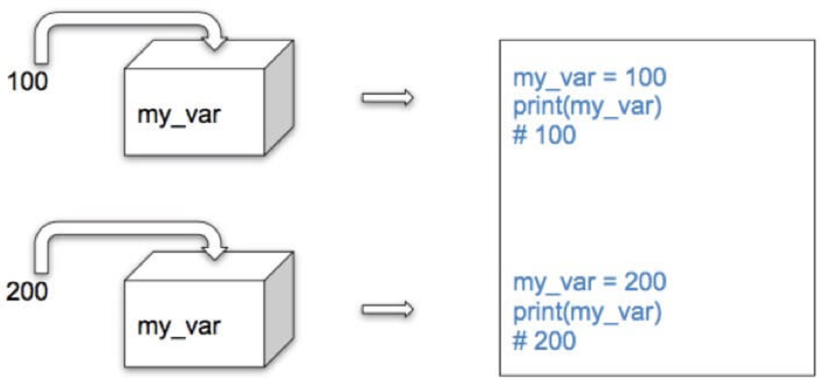

### ＜変数のメリット＞

#### 1. 文字列/数字が何を示しているのか分かりやすくなる。

■変数なし

```python
print(70 / (1.7 ** 2))
```

```
24.221453287197235
```

■変数あり

```python
weight = 70
height = 170
bmi = weight / ((height/100) ** 2)
print(bmi)
```

```
24.221453287197235
```

#### 2. 値を変更する際に、全ての値を変更する必要がなくなる。

■変数なし

```python
print(10 * 1)
print(10 * 2)
print(10 * 3)
print(10 * 4)
print(10 * 5)
```

```
10
20
30
40
50
```

■変数あり

```python
number = 10
print(number * 1)
print(number * 2)
print(number * 3)
print(number * 4)
print(number * 5)
```

```
10
20
30
40
50
```

### 2.1. 変数の型

Pythonは変数の型宣言をする必要がないが、意識はしておく必要はある。  
型の種類の一部を以下に示す。

| 型 | 型の説明 |
| --- | --- |
| int | 数値型（整数） |
| float | 浮動小数点数型 |
| str | 文字列型 |
| bool | 論理値(True, False) |

```python
 # int型
num_01 = 10
```

```python
type(num_01)
```

```
int
```

```python
# float型
num_02 = 16.93
```

```python
type(num_02)
```

```
float
```

```python
# str型
char = "Character"
```

```python
# bool型
flag = True
```

```python
# 変数同士の代数演算子による計算
num_03 = num_01 - num_02
print(num_03)
```

```
-6.93
```

```python
char01 = char + char
print(char01)
```

```
CharacterCharacter
```

型の変換も可能。

```python
# int型をstr型に変換
str(num_01)
```

```
'10'
```

### 2.2. 文字列と変数を同時に出力する方法。

```python
# 方法① formatを使う
print("変数num_01の値： {0}".format(num_0１))
print("変数num_02の値： {0}, 変数num_03の値: {1}".format(num_02, num_03))
```

[output not shown]

```python
# 方法② 文字列を連結する
print("変数num_01の値: " + str(num_01) )
print("変数num_02の値: " + str(num_02) + ", 変数num_03の型: " + str(num_03))
```

[output not shown]

#### 問題２：以下の計算問題を変数を用いて解いてみましょう。（3分）

1. 2000円を支払って「100円のりんごを5個」と「200円のバナナを3個」買いました。お釣りはいくらでしょうか。

```python
money = 2000
apple_price = 100
apple_num = 5
banana_price = 200
banana_num = 3

otsuri = money-(apple_price*apple_num + banana_price*banana_num)
print(otsuri)
```

```
900
```

1. A君は1000円を支払って「100円のりんごを6個」買いました。B君は500円を支払って「200円のバナナを2個」買いました。  
   A君とB君のお釣りはそれぞれいくらでしょうか。

```python
money_A = 1000
money_B = 500
apple_price = 100
apple_num = 6
banana_price = 200
banana_num = 2

otsuri_A = 1000-(apple_price*apple_num)
otsuri_B = 500-(banana_price*banana_num)

print("Aくんのお釣り： {0}円, Bくんのお釣り: {1}円".format(otsuri_A, otsuri_B))
```

```
Aくんのお釣り： 400円, Bくんのお釣り: 100円
```